# R Notebook

7/10/19 Yesterday I finished collecting all of my temperature sensors, and today begins the data analysis.

Goals for today: Figure out how to use Github Format temperature data

Work flow I’ve got an individual csv file for each sensor, so I need to read all of these in and combine the data. I need to rename each number to the sensor location. I need to round all the times to the nearest 10 minute interval so they line up.

Format the data to work with.

```
[1] 70415
```

Before I can plot, I have to subset the data in ways that I want it all plotted

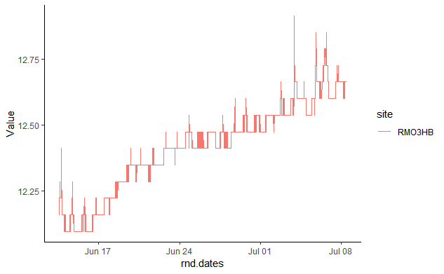

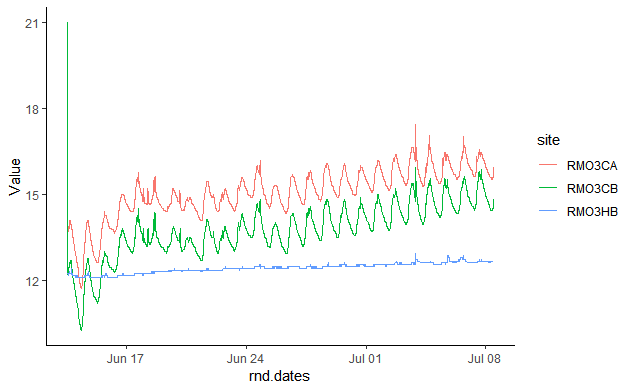

Ridge plots- show distribution JP was thinking I should make them with both the channel head and downstream sites together and color coded by elevation- we shall see

Spreading the data in order to do some math between heads and downstream sites

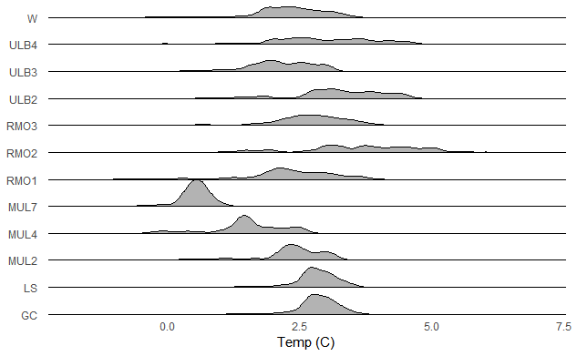

Plots of diff vs air

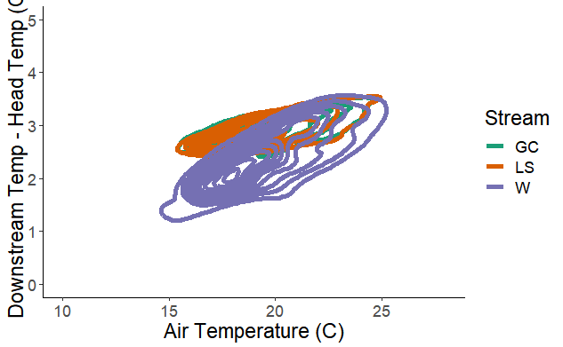

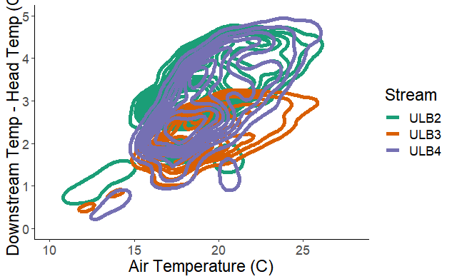

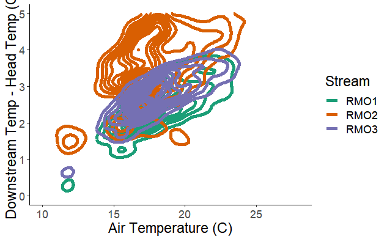

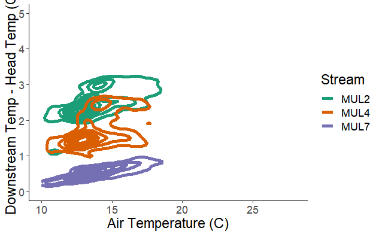

7-15-19 Final Plots that are going on the SURP poster Goals: Convey general temperature trends: -that the channel heads have almost constant temperatures -that stream water is cooler in high elevations -explore the relationship between mean annual air temperature and groundwater temperature - explore how water warms at different elevations and distances

Plots I will make: -ridge plots with head and c -general timeseries -Head vs airT -mean airT vs mean waterT -mean airT vs mean diff or diff vs airT

Ridge plots with head and C

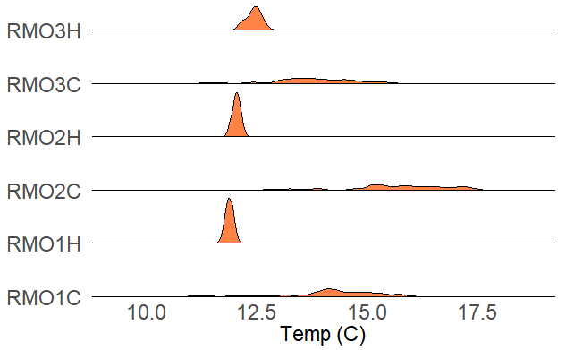

General timeseries- Not working, gave up

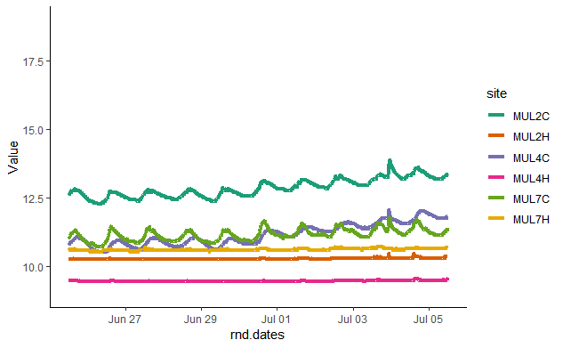

-Head vs airT -mean airT vs mean waterT -mean airT vs mean diff or diff vs airT

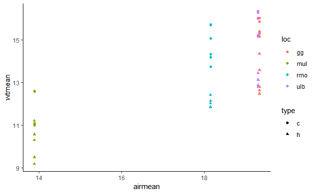

Basic time series

[figure not shown]

[figure not shown]

[figure not shown]

```
Column `site` joining character vector and factor, coercing into character vector
```

[figure not shown]

New plot for condensed slide, plotting airT vs headT and downstreamT